# Сборный проект: Исследование данных интернет-магазина компьютерных игр **«Стримчик»**

**Описание проекта:**  
Проект подразумевает анализ данных интернет-магазина компьютерных игр **«Стримчик»**, который продаёт игры по всему миру. Основная цель проекта — выявить закономерности, определяющие успешность игры, чтобы выбрать наиболее перспективные продукты для продвижения и спланировать рекламные кампании

Ключевые задачи:

1. **Подготовка данных:**
   - Приведение данных к нужным форматам, обработка пропусков, корректировка значений, таких как "tbd", в данных о рейтингах пользователей.
   - Добавление столбца с суммарными продажами игр по всем регионам.
2. **Исследовательский анализ данных:**
   - Анализ изменений в выпуске игр по годам и продаж по платформам. Выбор платформ с наибольшими продажами и анализ их жизненного цикла.
   - Анализ отзывов пользователей и критиков, определение корреляции между оценками и продажами на популярных платформах.
   - Исследование распределения игр по жанрам и определение самых прибыльных жанров.
3. **Портрет пользователя каждого региона (NA, EU, JP):**
   - Определение самых популярных платформ и жанров в каждом регионе.
   - Оценка влияния возрастных рейтингов ESRB на продажи в каждом регионе.
4. **Проверка гипотез:**
   - Сравнение пользовательских рейтингов платформ Xbox One и PC.
   - Сравнение пользовательских рейтингов жанров Action и Sports.

Таким образом, основной акцент в проекте делается на анализе данных о продажах игр, жанрах и платформах для выявления успешных стратегий продвижения и планирования рекламных кампаний.

## Загрузка данных

Загрузим данные и зучим общую информацию о датасете

```python
# Импорт библиотек
import pandas as pd
import matplotlib.pyplot as plt
import numpy as np
from scipy import stats as st
```

```python
try:
    data = pd.read_csv('/datasets/games.csv')  # Для практикума
except FileNotFoundError:
    try:
        data = pd.read_csv('../Модуль 1 спринт 1/games.csv')  # Если файл локальный
    except FileNotFoundError:
        try:
            data = pd.read_csv('/content/drive/MyDrive/Colab Notebooks/Модуль 1/Модуль 1 спринт 1/real_estate_data.csv', sep='\t')  # Для Google Colab
        except FileNotFoundError:
            print('Файл не найден ни в одном из указанных мест.')
```

**Описание данных:**

**data**

- `Name` — название игры
- `Platform` — платформа
- `Year_of_Release` — год выпуска
- `Genre` — жанр игры
- `NA_sales` — продажи в Северной Америке (миллионы проданных копий)
- `EU_sales` — продажи в Европе (миллионы проданных копий)
- `JP_sales` — продажи в Японии (миллионы проданных копий)
- `Other_sales` — продажи в других странах (миллионы проданных копий)
- `Critic_Score` — оценка критиков (максимум 100)
- `User_Score` — оценка пользователей (максимум 10)
- `Rating` — рейтинг от организации ESRB (англ. Entertainment Software Rating Board). Эта ассоциация определяет рейтинг компьютерных игр и присваивает им подходящую возрастную категорию.

```python
# Вывод на экран датесета
display(data.head(10))
data.tail(10)
```

|  | Name | Platform | Year_of_Release | Genre | NA_sales | EU_sales | JP_sales | Other_sales | Critic_Score | User_Score | Rating |
| --- | --- | --- | --- | --- | --- | --- | --- | --- | --- | --- | --- |
| 0 | Wii Sports | Wii | 2006.0 | Sports | 41.36 | 28.96 | 3.77 | 8.45 | 76.0 | 8 | E |
| 1 | Super Mario Bros. | NES | 1985.0 | Platform | 29.08 | 3.58 | 6.81 | 0.77 | NaN | NaN | NaN |
| 2 | Mario Kart Wii | Wii | 2008.0 | Racing | 15.68 | 12.76 | 3.79 | 3.29 | 82.0 | 8.3 | E |
| 3 | Wii Sports Resort | Wii | 2009.0 | Sports | 15.61 | 10.93 | 3.28 | 2.95 | 80.0 | 8 | E |
| 4 | Pokemon Red/Pokemon Blue | GB | 1996.0 | Role-Playing | 11.27 | 8.89 | 10.22 | 1.00 | NaN | NaN | NaN |
| 5 | Tetris | GB | 1989.0 | Puzzle | 23.20 | 2.26 | 4.22 | 0.58 | NaN | NaN | NaN |
| 6 | New Super Mario Bros. | DS | 2006.0 | Platform | 11.28 | 9.14 | 6.50 | 2.88 | 89.0 | 8.5 | E |
| 7 | Wii Play | Wii | 2006.0 | Misc | 13.96 | 9.18 | 2.93 | 2.84 | 58.0 | 6.6 | E |
| 8 | New Super Mario Bros. Wii | Wii | 2009.0 | Platform | 14.44 | 6.94 | 4.70 | 2.24 | 87.0 | 8.4 | E |
| 9 | Duck Hunt | NES | 1984.0 | Shooter | 26.93 | 0.63 | 0.28 | 0.47 | NaN | NaN | NaN |

|  | Name | Platform | Year_of_Release | Genre | NA_sales | EU_sales | JP_sales | Other_sales | Critic_Score | User_Score | Rating |
| --- | --- | --- | --- | --- | --- | --- | --- | --- | --- | --- | --- |
| 16705 | 15 Days | PC | 2009.0 | Adventure | 0.00 | 0.01 | 0.00 | 0.0 | 63.0 | 5.8 | NaN |
| 16706 | Men in Black II: Alien Escape | GC | 2003.0 | Shooter | 0.01 | 0.00 | 0.00 | 0.0 | NaN | tbd | T |
| 16707 | Aiyoku no Eustia | PSV | 2014.0 | Misc | 0.00 | 0.00 | 0.01 | 0.0 | NaN | NaN | NaN |
| 16708 | Woody Woodpecker in Crazy Castle 5 | GBA | 2002.0 | Platform | 0.01 | 0.00 | 0.00 | 0.0 | NaN | NaN | NaN |
| 16709 | SCORE International Baja 1000: The Official Game | PS2 | 2008.0 | Racing | 0.00 | 0.00 | 0.00 | 0.0 | NaN | NaN | NaN |
| 16710 | Samurai Warriors: Sanada Maru | PS3 | 2016.0 | Action | 0.00 | 0.00 | 0.01 | 0.0 | NaN | NaN | NaN |
| 16711 | LMA Manager 2007 | X360 | 2006.0 | Sports | 0.00 | 0.01 | 0.00 | 0.0 | NaN | NaN | NaN |
| 16712 | Haitaka no Psychedelica | PSV | 2016.0 | Adventure | 0.00 | 0.00 | 0.01 | 0.0 | NaN | NaN | NaN |
| 16713 | Spirits & Spells | GBA | 2003.0 | Platform | 0.01 | 0.00 | 0.00 | 0.0 | NaN | NaN | NaN |
| 16714 | Winning Post 8 2016 | PSV | 2016.0 | Simulation | 0.00 | 0.00 | 0.01 | 0.0 | NaN | NaN | NaN |

**Изучим структуру data**

```python
data.info()
```

```
<class 'pandas.core.frame.DataFrame'>
RangeIndex: 16715 entries, 0 to 16714
Data columns (total 11 columns):
 #   Column           Non-Null Count  Dtype
---  ------           --------------  -----
 0   Name             16713 non-null  object
 1   Platform         16715 non-null  object
 2   Year_of_Release  16446 non-null  float64
 3   Genre            16713 non-null  object
 4   NA_sales         16715 non-null  float64
 5   EU_sales         16715 non-null  float64
 6   JP_sales         16715 non-null  float64
 7   Other_sales      16715 non-null  float64
 8   Critic_Score     8137 non-null   float64
 9   User_Score       10014 non-null  object
 10  Rating           9949 non-null   object
dtypes: float64(6), object(5)
memory usage: 1.4+ MB
```

Построим гистограммы по числовым столбцам датафрейма

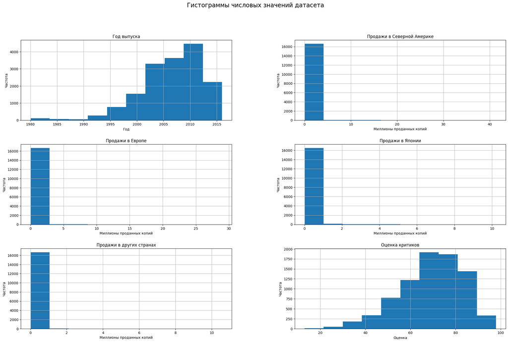

```python
axes = data.hist(figsize = (25,15))
axes[0,0].set_title('Год выпуска')
axes[0,0].set_xlabel('Год')
axes[0,0].set_ylabel('Частота')

axes[0,1].set_title('Продажи в Северной Америке')
axes[0,1].set_xlabel('Миллионы проданных копий')
axes[0,1].set_ylabel('Частота')

axes[1,0].set_title('Продажи в Европе')
axes[1,0].set_xlabel('Миллионы проданных копий')
axes[1,0].set_ylabel('Частота')

axes[1,1].set_title('Продажи в Японии')
axes[1,1].set_xlabel('Миллионы проданных копий')
axes[1,1].set_ylabel('Частота')

axes[2,0].set_title('Продажи в других странах')
axes[2,0].set_xlabel('Миллионы проданных копий')
axes[2,0].set_ylabel('Частота')

axes[2,1].set_title('Оценка критиков')
axes[2,1].set_xlabel('Оценка')
axes[2,1].set_ylabel('Частота')

plt.suptitle('Гистограммы числовых значений датасета', ha='center', fontsize='xx-large')
plt.show()
```

**Промежуточный итог:**

- Столбец `Year_of_Release` возможно должене иметь тип данных - `datetime` или `int`;
- Требуется выоплнить предобработку данных из за наличии пропусков и перевести столбцы в змеиный регистр.

## Подготовка данных

Выполним предобработку данных для дальнейшего анализа

**Определим количество пропущенных значений в каждом столбце**

```python
data.isna().sum()
```

```
Name                  2
Platform              0
Year_of_Release     269
Genre                 2
NA_sales              0
EU_sales              0
JP_sales              0
Other_sales           0
Critic_Score       8578
User_Score         6701
Rating             6766
dtype: int64
```

- `Year_of_Release` - год выпуска, 1,61% пропусков. Можно удалить;
- `Critic_Score` — оценки критиков (максимум 100), с более чем 50% пропусков;
- `User_Score` — оценки пользователей (максимум 10), с более чем 40% пропусков;
- `Rating` — рейтинг от организации ESRB, с более чем 40% пропусков.

Каждый из этих столбцов (как и другие) важен для проведения достоверного анализа данных.

**Переименуем столбцы**

```python
data = data.rename(columns={
    'Name':'name',
    'Platform':'platform',
    'Year_of_Release':'year_of_release',
    'Genre':'genre',
    'NA_sales':'na_sales',
    'EU_sales':'eu_sales',
    'JP_sales':'jp_sales',
    'Other_sales':'other_sales',
    'Critic_Score':'critic_score',
    'User_Score':'user_score',
    'Rating':'rating'
})
data.head()
```

|  | name | platform | year_of_release | genre | na_sales | eu_sales | jp_sales | other_sales | critic_score | user_score | rating |
| --- | --- | --- | --- | --- | --- | --- | --- | --- | --- | --- | --- |
| 0 | Wii Sports | Wii | 2006.0 | Sports | 41.36 | 28.96 | 3.77 | 8.45 | 76.0 | 8 | E |
| 1 | Super Mario Bros. | NES | 1985.0 | Platform | 29.08 | 3.58 | 6.81 | 0.77 | NaN | NaN | NaN |
| 2 | Mario Kart Wii | Wii | 2008.0 | Racing | 15.68 | 12.76 | 3.79 | 3.29 | 82.0 | 8.3 | E |
| 3 | Wii Sports Resort | Wii | 2009.0 | Sports | 15.61 | 10.93 | 3.28 | 2.95 | 80.0 | 8 | E |
| 4 | Pokemon Red/Pokemon Blue | GB | 1996.0 | Role-Playing | 11.27 | 8.89 | 10.22 | 1.00 | NaN | NaN | NaN |

Замена прошла успешно

**Проверим на наличие дубликатов датафрейме**

Проверим наличие явных дубликатов

```python
print('Количество явных дубликатов в data:', data.duplicated().sum())
```

```
Количество явных дубликатов в data: 0
```

Явных дубликатов не обнаружено.

Проверим столбцы `name`, `platform`, `year_of_release` на наличие неявных дубликатов

```python
duplicates = data[data.duplicated(subset=['name', 'platform', 'year_of_release'], keep=False)]
duplicates
```

|  | name | platform | year_of_release | genre | na_sales | eu_sales | jp_sales | other_sales | critic_score | user_score | rating |
| --- | --- | --- | --- | --- | --- | --- | --- | --- | --- | --- | --- |
| 604 | Madden NFL 13 | PS3 | 2012.0 | Sports | 2.11 | 0.22 | 0.00 | 0.23 | 83.0 | 5.5 | E |
| 659 | NaN | GEN | 1993.0 | NaN | 1.78 | 0.53 | 0.00 | 0.08 | NaN | NaN | NaN |
| 14244 | NaN | GEN | 1993.0 | NaN | 0.00 | 0.00 | 0.03 | 0.00 | NaN | NaN | NaN |
| 16230 | Madden NFL 13 | PS3 | 2012.0 | Sports | 0.00 | 0.01 | 0.00 | 0.00 | 83.0 | 5.5 | E |

Проверка выявила наличие неявных дубликатов. Удалим два пропуска в столбце `name`, что было сделано позже в проекте. Также удалим строку 16230, так как она содержит меньше данных

```python
data = data.drop(16230)
# Проведем проверку
duplicates = data[data.duplicated(subset=['name', 'platform', 'year_of_release'], keep=False)]
duplicates
```

|  | name | platform | year_of_release | genre | na_sales | eu_sales | jp_sales | other_sales | critic_score | user_score | rating |
| --- | --- | --- | --- | --- | --- | --- | --- | --- | --- | --- | --- |
| 659 | NaN | GEN | 1993.0 | NaN | 1.78 | 0.53 | 0.00 | 0.08 | NaN | NaN | NaN |
| 14244 | NaN | GEN | 1993.0 | NaN | 0.00 | 0.00 | 0.03 | 0.00 | NaN | NaN | NaN |

**Обработаем столбец `name`**

Удалим два проска в столбце `name`. Так как востановить название игры не возможно

```python
data = data.dropna(subset=['name'])
display(data.tail(10))
data.shape
```

|  | name | platform | year_of_release | genre | na_sales | eu_sales | jp_sales | other_sales | critic_score | user_score | rating |
| --- | --- | --- | --- | --- | --- | --- | --- | --- | --- | --- | --- |
| 16705 | 15 Days | PC | 2009.0 | Adventure | 0.00 | 0.01 | 0.00 | 0.0 | 63.0 | 5.8 | NaN |
| 16706 | Men in Black II: Alien Escape | GC | 2003.0 | Shooter | 0.01 | 0.00 | 0.00 | 0.0 | NaN | tbd | T |
| 16707 | Aiyoku no Eustia | PSV | 2014.0 | Misc | 0.00 | 0.00 | 0.01 | 0.0 | NaN | NaN | NaN |
| 16708 | Woody Woodpecker in Crazy Castle 5 | GBA | 2002.0 | Platform | 0.01 | 0.00 | 0.00 | 0.0 | NaN | NaN | NaN |
| 16709 | SCORE International Baja 1000: The Official Game | PS2 | 2008.0 | Racing | 0.00 | 0.00 | 0.00 | 0.0 | NaN | NaN | NaN |
| 16710 | Samurai Warriors: Sanada Maru | PS3 | 2016.0 | Action | 0.00 | 0.00 | 0.01 | 0.0 | NaN | NaN | NaN |
| 16711 | LMA Manager 2007 | X360 | 2006.0 | Sports | 0.00 | 0.01 | 0.00 | 0.0 | NaN | NaN | NaN |
| 16712 | Haitaka no Psychedelica | PSV | 2016.0 | Adventure | 0.00 | 0.00 | 0.01 | 0.0 | NaN | NaN | NaN |
| 16713 | Spirits & Spells | GBA | 2003.0 | Platform | 0.01 | 0.00 | 0.00 | 0.0 | NaN | NaN | NaN |
| 16714 | Winning Post 8 2016 | PSV | 2016.0 | Simulation | 0.00 | 0.00 | 0.01 | 0.0 | NaN | NaN | NaN |

```
(16712, 11)
```

Проверка показала, что неявных дубликатов нет.

```python
# Проверим наличие пропусков в столбцах
data.isna().sum()
```

```
name                  0
platform              0
year_of_release     269
genre                 0
na_sales              0
eu_sales              0
jp_sales              0
other_sales           0
critic_score       8576
user_score         6699
rating             6764
dtype: int64
```

Вывод: Из столбца `name` были удаленны пропуски

**Обработаем столбец `year_of_release`**

Преобразуем тип данных в столбце `year_of_release`

```python
data['year_of_release'] = data['year_of_release'].astype('Int64')
data['year_of_release'].head()
```

```
0    2006
1    1985
2    2008
3    2009
4    1996
Name: year_of_release, dtype: Int64
```

Процент пропусков в данном столбце составляет 1,61%, поэтому было решено удалить строки с пропусками в этом столбце

```python
data = data.dropna(subset=['year_of_release'])
display(data.tail(10))
data.shape
```

|  | name | platform | year_of_release | genre | na_sales | eu_sales | jp_sales | other_sales | critic_score | user_score | rating |
| --- | --- | --- | --- | --- | --- | --- | --- | --- | --- | --- | --- |
| 16705 | 15 Days | PC | 2009 | Adventure | 0.00 | 0.01 | 0.00 | 0.0 | 63.0 | 5.8 | NaN |
| 16706 | Men in Black II: Alien Escape | GC | 2003 | Shooter | 0.01 | 0.00 | 0.00 | 0.0 | NaN | tbd | T |
| 16707 | Aiyoku no Eustia | PSV | 2014 | Misc | 0.00 | 0.00 | 0.01 | 0.0 | NaN | NaN | NaN |
| 16708 | Woody Woodpecker in Crazy Castle 5 | GBA | 2002 | Platform | 0.01 | 0.00 | 0.00 | 0.0 | NaN | NaN | NaN |
| 16709 | SCORE International Baja 1000: The Official Game | PS2 | 2008 | Racing | 0.00 | 0.00 | 0.00 | 0.0 | NaN | NaN | NaN |
| 16710 | Samurai Warriors: Sanada Maru | PS3 | 2016 | Action | 0.00 | 0.00 | 0.01 | 0.0 | NaN | NaN | NaN |
| 16711 | LMA Manager 2007 | X360 | 2006 | Sports | 0.00 | 0.01 | 0.00 | 0.0 | NaN | NaN | NaN |
| 16712 | Haitaka no Psychedelica | PSV | 2016 | Adventure | 0.00 | 0.00 | 0.01 | 0.0 | NaN | NaN | NaN |
| 16713 | Spirits & Spells | GBA | 2003 | Platform | 0.01 | 0.00 | 0.00 | 0.0 | NaN | NaN | NaN |
| 16714 | Winning Post 8 2016 | PSV | 2016 | Simulation | 0.00 | 0.00 | 0.01 | 0.0 | NaN | NaN | NaN |

```
(16443, 11)
```

```python
print(f"Диапазон в столбце year_of_release: с {data['year_of_release'].min()} до {data['year_of_release'].max()}")
```

```
Диапазон в столбце year_of_release: с 1980 до 2016
```

```python
# Проверим наличие пропусков в столбцах
data.isna().sum()
```

```
name                  0
platform              0
year_of_release       0
genre                 0
na_sales              0
eu_sales              0
jp_sales              0
other_sales           0
critic_score       8461
user_score         6605
rating             6676
dtype: int64
```

Вывод: Пропуски в столбце `year_of_release`, составляющие 1,61% от общего числа значений, были удалены.

**Обработаем столбец `critic_score`**

```python
# Ознакомимся с пропусками
data[data['critic_score'].isna()].head(10)
```

|  | name | platform | year_of_release | genre | na_sales | eu_sales | jp_sales | other_sales | critic_score | user_score | rating |
| --- | --- | --- | --- | --- | --- | --- | --- | --- | --- | --- | --- |
| 1 | Super Mario Bros. | NES | 1985 | Platform | 29.08 | 3.58 | 6.81 | 0.77 | NaN | NaN | NaN |
| 4 | Pokemon Red/Pokemon Blue | GB | 1996 | Role-Playing | 11.27 | 8.89 | 10.22 | 1.00 | NaN | NaN | NaN |
| 5 | Tetris | GB | 1989 | Puzzle | 23.20 | 2.26 | 4.22 | 0.58 | NaN | NaN | NaN |
| 9 | Duck Hunt | NES | 1984 | Shooter | 26.93 | 0.63 | 0.28 | 0.47 | NaN | NaN | NaN |
| 10 | Nintendogs | DS | 2005 | Simulation | 9.05 | 10.95 | 1.93 | 2.74 | NaN | NaN | NaN |
| 12 | Pokemon Gold/Pokemon Silver | GB | 1999 | Role-Playing | 9.00 | 6.18 | 7.20 | 0.71 | NaN | NaN | NaN |
| 18 | Super Mario World | SNES | 1990 | Platform | 12.78 | 3.75 | 3.54 | 0.55 | NaN | NaN | NaN |
| 20 | Pokemon Diamond/Pokemon Pearl | DS | 2006 | Role-Playing | 6.38 | 4.46 | 6.04 | 1.36 | NaN | NaN | NaN |
| 21 | Super Mario Land | GB | 1989 | Platform | 10.83 | 2.71 | 4.18 | 0.42 | NaN | NaN | NaN |
| 22 | Super Mario Bros. 3 | NES | 1988 | Platform | 9.54 | 3.44 | 3.84 | 0.46 | NaN | NaN | NaN |

Я узнал, что лучше использовать "заглушки" вместо удаления данных. Поскольку нет явной зависимости для определения оценок критиков, это позволит сохранить важные строки и целостность датафрейма. При построении графиков можно будет исключить заглушки для более корректного анализа

```python
# Заменим пропуски с помощью метода fillna()
data['critic_score'] = data['critic_score'].fillna(-1)
data.head(10)
```

|  | name | platform | year_of_release | genre | na_sales | eu_sales | jp_sales | other_sales | critic_score | user_score | rating |
| --- | --- | --- | --- | --- | --- | --- | --- | --- | --- | --- | --- |
| 0 | Wii Sports | Wii | 2006 | Sports | 41.36 | 28.96 | 3.77 | 8.45 | 76.0 | 8 | E |
| 1 | Super Mario Bros. | NES | 1985 | Platform | 29.08 | 3.58 | 6.81 | 0.77 | -1.0 | NaN | NaN |
| 2 | Mario Kart Wii | Wii | 2008 | Racing | 15.68 | 12.76 | 3.79 | 3.29 | 82.0 | 8.3 | E |
| 3 | Wii Sports Resort | Wii | 2009 | Sports | 15.61 | 10.93 | 3.28 | 2.95 | 80.0 | 8 | E |
| 4 | Pokemon Red/Pokemon Blue | GB | 1996 | Role-Playing | 11.27 | 8.89 | 10.22 | 1.00 | -1.0 | NaN | NaN |
| 5 | Tetris | GB | 1989 | Puzzle | 23.20 | 2.26 | 4.22 | 0.58 | -1.0 | NaN | NaN |
| 6 | New Super Mario Bros. | DS | 2006 | Platform | 11.28 | 9.14 | 6.50 | 2.88 | 89.0 | 8.5 | E |
| 7 | Wii Play | Wii | 2006 | Misc | 13.96 | 9.18 | 2.93 | 2.84 | 58.0 | 6.6 | E |
| 8 | New Super Mario Bros. Wii | Wii | 2009 | Platform | 14.44 | 6.94 | 4.70 | 2.24 | 87.0 | 8.4 | E |
| 9 | Duck Hunt | NES | 1984 | Shooter | 26.93 | 0.63 | 0.28 | 0.47 | -1.0 | NaN | NaN |

```python
# Проверим наличие пропусков в столбцах
data.isna().sum()
```

```
name                  0
platform              0
year_of_release       0
genre                 0
na_sales              0
eu_sales              0
jp_sales              0
other_sales           0
critic_score          0
user_score         6605
rating             6676
dtype: int64
```

Вывод: Для сохранения данных было принято решение использовать "заглушки" в столбце `critic_score`, что позволит избежать удаления строк и сохранить целостность датафрейма

**Обработаем столбец `user_score`**

```python
# Ознакомимся с пропусками
display(data[data['user_score'].isna()].head(10))
data[data['user_score'].isna()].shape
```

|  | name | platform | year_of_release | genre | na_sales | eu_sales | jp_sales | other_sales | critic_score | user_score | rating |
| --- | --- | --- | --- | --- | --- | --- | --- | --- | --- | --- | --- |
| 1 | Super Mario Bros. | NES | 1985 | Platform | 29.08 | 3.58 | 6.81 | 0.77 | -1.0 | NaN | NaN |
| 4 | Pokemon Red/Pokemon Blue | GB | 1996 | Role-Playing | 11.27 | 8.89 | 10.22 | 1.00 | -1.0 | NaN | NaN |
| 5 | Tetris | GB | 1989 | Puzzle | 23.20 | 2.26 | 4.22 | 0.58 | -1.0 | NaN | NaN |
| 9 | Duck Hunt | NES | 1984 | Shooter | 26.93 | 0.63 | 0.28 | 0.47 | -1.0 | NaN | NaN |
| 10 | Nintendogs | DS | 2005 | Simulation | 9.05 | 10.95 | 1.93 | 2.74 | -1.0 | NaN | NaN |
| 12 | Pokemon Gold/Pokemon Silver | GB | 1999 | Role-Playing | 9.00 | 6.18 | 7.20 | 0.71 | -1.0 | NaN | NaN |
| 18 | Super Mario World | SNES | 1990 | Platform | 12.78 | 3.75 | 3.54 | 0.55 | -1.0 | NaN | NaN |
| 20 | Pokemon Diamond/Pokemon Pearl | DS | 2006 | Role-Playing | 6.38 | 4.46 | 6.04 | 1.36 | -1.0 | NaN | NaN |
| 21 | Super Mario Land | GB | 1989 | Platform | 10.83 | 2.71 | 4.18 | 0.42 | -1.0 | NaN | NaN |
| 22 | Super Mario Bros. 3 | NES | 1988 | Platform | 9.54 | 3.44 | 3.84 | 0.46 | -1.0 | NaN | NaN |

```
(6605, 11)
```

В данном столбце ситуация аналогична столбцу `critic_score`. Для замены пропусков будем использовать заглушки.

```python
# Заменим пропуски с помощью метода fillna()
data['user_score'] = data['user_score'].fillna(-2)
data.head(10)
```

|  | name | platform | year_of_release | genre | na_sales | eu_sales | jp_sales | other_sales | critic_score | user_score | rating |
| --- | --- | --- | --- | --- | --- | --- | --- | --- | --- | --- | --- |
| 0 | Wii Sports | Wii | 2006 | Sports | 41.36 | 28.96 | 3.77 | 8.45 | 76.0 | 8 | E |
| 1 | Super Mario Bros. | NES | 1985 | Platform | 29.08 | 3.58 | 6.81 | 0.77 | -1.0 | -2 | NaN |
| 2 | Mario Kart Wii | Wii | 2008 | Racing | 15.68 | 12.76 | 3.79 | 3.29 | 82.0 | 8.3 | E |
| 3 | Wii Sports Resort | Wii | 2009 | Sports | 15.61 | 10.93 | 3.28 | 2.95 | 80.0 | 8 | E |
| 4 | Pokemon Red/Pokemon Blue | GB | 1996 | Role-Playing | 11.27 | 8.89 | 10.22 | 1.00 | -1.0 | -2 | NaN |
| 5 | Tetris | GB | 1989 | Puzzle | 23.20 | 2.26 | 4.22 | 0.58 | -1.0 | -2 | NaN |
| 6 | New Super Mario Bros. | DS | 2006 | Platform | 11.28 | 9.14 | 6.50 | 2.88 | 89.0 | 8.5 | E |
| 7 | Wii Play | Wii | 2006 | Misc | 13.96 | 9.18 | 2.93 | 2.84 | 58.0 | 6.6 | E |
| 8 | New Super Mario Bros. Wii | Wii | 2009 | Platform | 14.44 | 6.94 | 4.70 | 2.24 | 87.0 | 8.4 | E |
| 9 | Duck Hunt | NES | 1984 | Shooter | 26.93 | 0.63 | 0.28 | 0.47 | -1.0 | -2 | NaN |

```python
data.query('user_score == "tbd"')
```

|  | name | platform | year_of_release | genre | na_sales | eu_sales | jp_sales | other_sales | critic_score | user_score | rating |
| --- | --- | --- | --- | --- | --- | --- | --- | --- | --- | --- | --- |
| 119 | Zumba Fitness | Wii | 2010 | Sports | 3.45 | 2.59 | 0.0 | 0.66 | -1.0 | tbd | E |
| 301 | Namco Museum: 50th Anniversary | PS2 | 2005 | Misc | 2.08 | 1.35 | 0.0 | 0.54 | 61.0 | tbd | E10+ |
| 520 | Zumba Fitness 2 | Wii | 2011 | Sports | 1.51 | 1.03 | 0.0 | 0.27 | -1.0 | tbd | T |
| 645 | uDraw Studio | Wii | 2010 | Misc | 1.65 | 0.57 | 0.0 | 0.20 | 71.0 | tbd | E |
| 718 | Just Dance Kids | Wii | 2010 | Misc | 1.52 | 0.54 | 0.0 | 0.18 | -1.0 | tbd | E |
| ... | ... | ... | ... | ... | ... | ... | ... | ... | ... | ... | ... |
| 16695 | Planet Monsters | GBA | 2001 | Action | 0.01 | 0.00 | 0.0 | 0.00 | 67.0 | tbd | E |
| 16697 | Bust-A-Move 3000 | GC | 2003 | Puzzle | 0.01 | 0.00 | 0.0 | 0.00 | 53.0 | tbd | E |
| 16698 | Mega Brain Boost | DS | 2008 | Puzzle | 0.01 | 0.00 | 0.0 | 0.00 | 48.0 | tbd | E |
| 16704 | Plushees | DS | 2008 | Simulation | 0.01 | 0.00 | 0.0 | 0.00 | -1.0 | tbd | E |
| 16706 | Men in Black II: Alien Escape | GC | 2003 | Shooter | 0.01 | 0.00 | 0.0 | 0.00 | -1.0 | tbd | T |

2376 rows × 11 columns

Также в столбце `user_score` присутствует значение `tbd` (to be determined — подлежит уточнению). Мы заменим `tbd` на `-2`, чтобы в дальнейшем можно было корректно строить графики.

```python
data['user_score'] = data['user_score'].replace('tbd', -2)
# проверим замену
data.query('user_score == "tbd"').shape
```

```
(0, 11)
```

Изменим тип данных на `float`, для удобства при анализе данных

```python
data['user_score'] = data['user_score'].astype('float')
data['user_score']
```

```
0        8.0
1       -2.0
2        8.3
3        8.0
4       -2.0
        ...
16710   -2.0
16711   -2.0
16712   -2.0
16713   -2.0
16714   -2.0
Name: user_score, Length: 16443, dtype: float64
```

```python
# Проверим наличие пропусков в столбцах
data.isna().sum()
```

```
name                  0
platform              0
year_of_release       0
genre                 0
na_sales              0
eu_sales              0
jp_sales              0
other_sales           0
critic_score          0
user_score            0
rating             6676
dtype: int64
```

**Обработаем столбец `rating`**

```python
# Ознакомимся с пропусками
data[data['rating'].isna()].head(10)
```

|  | name | platform | year_of_release | genre | na_sales | eu_sales | jp_sales | other_sales | critic_score | user_score | rating |
| --- | --- | --- | --- | --- | --- | --- | --- | --- | --- | --- | --- |
| 1 | Super Mario Bros. | NES | 1985 | Platform | 29.08 | 3.58 | 6.81 | 0.77 | -1.0 | -2.0 | NaN |
| 4 | Pokemon Red/Pokemon Blue | GB | 1996 | Role-Playing | 11.27 | 8.89 | 10.22 | 1.00 | -1.0 | -2.0 | NaN |
| 5 | Tetris | GB | 1989 | Puzzle | 23.20 | 2.26 | 4.22 | 0.58 | -1.0 | -2.0 | NaN |
| 9 | Duck Hunt | NES | 1984 | Shooter | 26.93 | 0.63 | 0.28 | 0.47 | -1.0 | -2.0 | NaN |
| 10 | Nintendogs | DS | 2005 | Simulation | 9.05 | 10.95 | 1.93 | 2.74 | -1.0 | -2.0 | NaN |
| 12 | Pokemon Gold/Pokemon Silver | GB | 1999 | Role-Playing | 9.00 | 6.18 | 7.20 | 0.71 | -1.0 | -2.0 | NaN |
| 18 | Super Mario World | SNES | 1990 | Platform | 12.78 | 3.75 | 3.54 | 0.55 | -1.0 | -2.0 | NaN |
| 20 | Pokemon Diamond/Pokemon Pearl | DS | 2006 | Role-Playing | 6.38 | 4.46 | 6.04 | 1.36 | -1.0 | -2.0 | NaN |
| 21 | Super Mario Land | GB | 1989 | Platform | 10.83 | 2.71 | 4.18 | 0.42 | -1.0 | -2.0 | NaN |
| 22 | Super Mario Bros. 3 | NES | 1988 | Platform | 9.54 | 3.44 | 3.84 | 0.46 | -1.0 | -2.0 | NaN |

Проверим столбец `rating` на уникальность

```python
data['rating'].unique()
```

```
array(['E', nan, 'M', 'T', 'E10+', 'K-A', 'AO', 'EC', 'RP'], dtype=object)
```

Данные рейтинги представляют собой систему оценки содержания видеоигр, используемую в Северной Америке. Вот расшифровка основных рейтингов:

1. E (Everyone): Подходит для всех возрастов. Может содержать минимальное насилие, комический юмор или легкие темы.
2. M (Mature): Для лиц от 17 лет и старше. Может включать интенсивное насилие, кровь, сексуальный контент и крепкие выражения.
3. T (Teen): Для подростков от 13 лет. Может содержать насилие, сугестивные темы, грубый юмор, минимальное количество крови и редкое использование крепких выражений.
4. E10+ (Everyone 10+): Для лиц от 10 лет и старше. Может включать больше мультипликационного или легкого насилия и слегка провокационные темы.
5. AO (Adults Only): Только для взрослых от 18 лет и старше. Может включать продолжительные сцены интенсивного насилия и/или графического сексуального содержания и наготы.
6. RP (Rating Pending): Рейтинг ожидается. Используется для игр, которые были представлены в ESRB и ожидают окончательного рейтинга.

Рейтинги K-A и EC являются устаревшими или менее распространенными:

- K-A (Kids to Adults): Старый рейтинг, предшественник E, использовавшийся до 1998 года.
- EC (Early Childhood): Для детей раннего возраста, обычно образовательные игры.

Эта система рейтингов помогает родителям и покупателям принимать информированные решения о приобретении и использовании видеоигр.

Пропуски в столбце `rating` могли возникнуть в случаях, когда `ESRB` рейтинг не использовался, так как этот рейтинг для США и Канады. Эти пропуски будут заменены на значение `unknown`, что позволит сохранить целостность данных и корректно учитывать все строки при анализе.

```python
data['rating'] = data['rating'].fillna('unknown')
data.head(10)
```

|  | name | platform | year_of_release | genre | na_sales | eu_sales | jp_sales | other_sales | critic_score | user_score | rating |
| --- | --- | --- | --- | --- | --- | --- | --- | --- | --- | --- | --- |
| 0 | Wii Sports | Wii | 2006 | Sports | 41.36 | 28.96 | 3.77 | 8.45 | 76.0 | 8.0 | E |
| 1 | Super Mario Bros. | NES | 1985 | Platform | 29.08 | 3.58 | 6.81 | 0.77 | -1.0 | -2.0 | unknown |
| 2 | Mario Kart Wii | Wii | 2008 | Racing | 15.68 | 12.76 | 3.79 | 3.29 | 82.0 | 8.3 | E |
| 3 | Wii Sports Resort | Wii | 2009 | Sports | 15.61 | 10.93 | 3.28 | 2.95 | 80.0 | 8.0 | E |
| 4 | Pokemon Red/Pokemon Blue | GB | 1996 | Role-Playing | 11.27 | 8.89 | 10.22 | 1.00 | -1.0 | -2.0 | unknown |
| 5 | Tetris | GB | 1989 | Puzzle | 23.20 | 2.26 | 4.22 | 0.58 | -1.0 | -2.0 | unknown |
| 6 | New Super Mario Bros. | DS | 2006 | Platform | 11.28 | 9.14 | 6.50 | 2.88 | 89.0 | 8.5 | E |
| 7 | Wii Play | Wii | 2006 | Misc | 13.96 | 9.18 | 2.93 | 2.84 | 58.0 | 6.6 | E |
| 8 | New Super Mario Bros. Wii | Wii | 2009 | Platform | 14.44 | 6.94 | 4.70 | 2.24 | 87.0 | 8.4 | E |
| 9 | Duck Hunt | NES | 1984 | Shooter | 26.93 | 0.63 | 0.28 | 0.47 | -1.0 | -2.0 | unknown |

```python
# Проверим наличие пропусков в столбцах
data.isna().sum()
```

```
name               0
platform           0
year_of_release    0
genre              0
na_sales           0
eu_sales           0
jp_sales           0
other_sales        0
critic_score       0
user_score         0
rating             0
dtype: int64
```

В ходе предобработки данных была проведена обработка пропусков столбцах, таких как **оценки критиков**, **оценки пользователей**, **рейтинг игр**, а также **год выпуска**. Были выявлены следующие причины пропусков:

**Пропуски в данных о годе выпуска:**

- Пропуски в столбце с годом выпуска могли возникнуть из-за ошибок при выгрузке данных или отсутствия информации о точной дате релиза для старых игр.

**Пропуски в столбце с оценками критиков и пользователей:**

- Пропуски могли возникнуть из-за отсутствия данных на момент сбора информации о некоторых играх. Например, если продажи игры были низкими, могло не накопиться достаточного количества отзывов для формирования окончательной оценки.

**Пропуски в столбце рейтинг:**

- Пропуски в столбце rating могли возникнуть в случаях, когда ESRB рейтинг не использовался (например для рынка Японии), так как этот рейтинг для рынка США и Канады.

**Суммарные продажи во всех регионах `total_sale`**

```python
data['total_sale'] = data['na_sales'] + data['eu_sales'] + data['jp_sales'] + data['other_sales']
data.head()
```

|  | name | platform | year_of_release | genre | na_sales | eu_sales | jp_sales | other_sales | critic_score | user_score | rating | total_sale |
| --- | --- | --- | --- | --- | --- | --- | --- | --- | --- | --- | --- | --- |
| 0 | Wii Sports | Wii | 2006 | Sports | 41.36 | 28.96 | 3.77 | 8.45 | 76.0 | 8.0 | E | 82.54 |
| 1 | Super Mario Bros. | NES | 1985 | Platform | 29.08 | 3.58 | 6.81 | 0.77 | -1.0 | -2.0 | unknown | 40.24 |
| 2 | Mario Kart Wii | Wii | 2008 | Racing | 15.68 | 12.76 | 3.79 | 3.29 | 82.0 | 8.3 | E | 35.52 |
| 3 | Wii Sports Resort | Wii | 2009 | Sports | 15.61 | 10.93 | 3.28 | 2.95 | 80.0 | 8.0 | E | 32.77 |
| 4 | Pokemon Red/Pokemon Blue | GB | 1996 | Role-Playing | 11.27 | 8.89 | 10.22 | 1.00 | -1.0 | -2.0 | unknown | 31.38 |

**Промежуточный итог:**

В этом разделе была проведена обработка пропусков в ключевых столбцах для сохранения целостности данных и повышения корректности последующего анализа. Основные шаги включали удаление строк с незначительным количеством пропусков, использование "заглушек" для сохранения данных, а также преобразование типов данных. Ниже приведены основные решения:

- **Обработка пропусков в столбце `year_of_release`**: Поскольку процент пропусков составил всего 1,61%, было решено удалить строки с отсутствующими значениями в этом столбце. Это решение не оказывает существенного влияния на целостность данных, но позволяет сохранить корректность анализа временных данных.
- **Обработка пропусков в столбце `critic_score`**: Вместо удаления строк с пропусками было решено использовать "заглушки". Это решение позволяет избежать потерь данных, сохраняя важные строки для дальнейшего анализа. Такие "заглушки" могут быть исключены из расчетов и визуализаций при необходимости.
- **Обработка пропусков в столбце `user_score`**: Аналогично столбцу `critic_score`, для сохранения данных использовались "заглушки". Дополнительно значения `tbd` были заменены на `-2`, что позволяет корректно обрабатывать эти значения при построении графиков.
- **Обработка столбца `rating`**: Пропуски в столбце рейтинга были заполнены значением `unknown`. Это решение позволяет сохранить строки для последующего анализа и исключить потерю данных.
- **Добавлен новый столбец `total_sale`**: Столбец `total_sale` содержит данные о суммарных продажах по всем регионам.

## Исследовательский анализ данных

##### Анализ изменений в выпуске игр по годам и продаж по платформам.

**Изучим сколько игр выпускалось в разные годы**

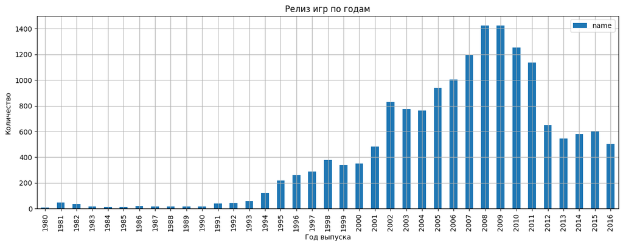

```python
# Построим график
(
    data.pivot_table(index='year_of_release', values='name', aggfunc='count')
    .plot(kind='bar',
          grid=True,
          figsize=(15, 5))
)

# Задание названия графика
plt.title('Релиз игр по годам')
plt.xlabel('Год выпуска')
plt.ylabel('Количество')

# Показать график
plt.show()
```

**Изучим как менялись продажи по платформам**

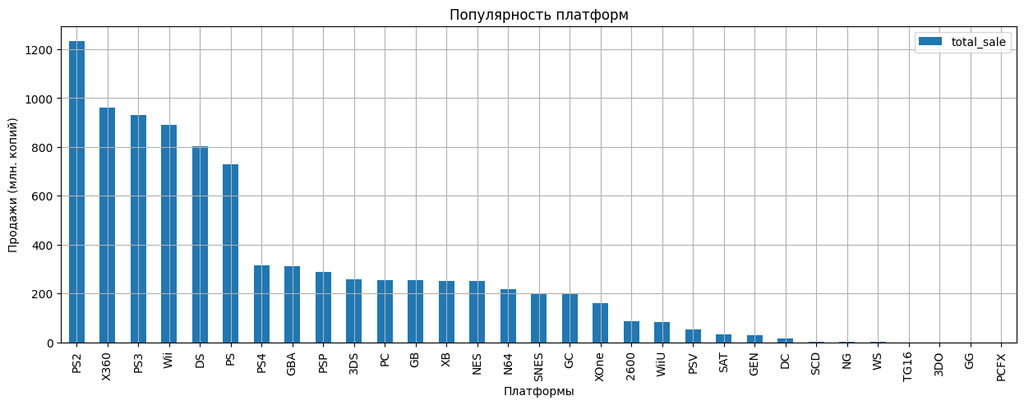

```python
# Построим график
(
    data.pivot_table(index='platform', values='total_sale', aggfunc='sum').sort_values('total_sale', ascending=False)
    .plot(kind='bar',
          grid=True,
          figsize=(15, 5))
)

# Задание названия графика
plt.title('Популярность платформ')
plt.xlabel('Платформы')
plt.ylabel('Продажи (млн. копий)')

# Показать график
plt.show()
```

Платформа PS2 лидирует по объему продаж. Продажи X360, PS3, Wii, DS и PS также находятся на высоком уровне, хотя и уступают PS2, но остаются среди лидеров на рынке по продажам.

##### Выбор платформ с наибольшими продажами и анализ их жизненного цикла.

**Выбор платформ с наибольшими продажами**

```python
top_platforms = list(data.groupby('platform')['total_sale'].sum().sort_values(ascending=False).index[:6])
top_platform = data.query('platform in @top_platforms')
top_platform
```

|  | name | platform | year_of_release | genre | na_sales | eu_sales | jp_sales | other_sales | critic_score | user_score | rating | total_sale |
| --- | --- | --- | --- | --- | --- | --- | --- | --- | --- | --- | --- | --- |
| 0 | Wii Sports | Wii | 2006 | Sports | 41.36 | 28.96 | 3.77 | 8.45 | 76.0 | 8.0 | E | 82.54 |
| 2 | Mario Kart Wii | Wii | 2008 | Racing | 15.68 | 12.76 | 3.79 | 3.29 | 82.0 | 8.3 | E | 35.52 |
| 3 | Wii Sports Resort | Wii | 2009 | Sports | 15.61 | 10.93 | 3.28 | 2.95 | 80.0 | 8.0 | E | 32.77 |
| 6 | New Super Mario Bros. | DS | 2006 | Platform | 11.28 | 9.14 | 6.50 | 2.88 | 89.0 | 8.5 | E | 29.80 |
| 7 | Wii Play | Wii | 2006 | Misc | 13.96 | 9.18 | 2.93 | 2.84 | 58.0 | 6.6 | E | 28.91 |
| ... | ... | ... | ... | ... | ... | ... | ... | ... | ... | ... | ... | ... |
| 16700 | Mezase!! Tsuri Master DS | DS | 2009 | Sports | 0.00 | 0.00 | 0.01 | 0.00 | -1.0 | -2.0 | unknown | 0.01 |
| 16704 | Plushees | DS | 2008 | Simulation | 0.01 | 0.00 | 0.00 | 0.00 | -1.0 | -2.0 | E | 0.01 |
| 16709 | SCORE International Baja 1000: The Official Game | PS2 | 2008 | Racing | 0.00 | 0.00 | 0.00 | 0.00 | -1.0 | -2.0 | unknown | 0.00 |
| 16710 | Samurai Warriors: Sanada Maru | PS3 | 2016 | Action | 0.00 | 0.00 | 0.01 | 0.00 | -1.0 | -2.0 | unknown | 0.01 |
| 16711 | LMA Manager 2007 | X360 | 2006 | Sports | 0.00 | 0.01 | 0.00 | 0.00 | -1.0 | -2.0 | unknown | 0.01 |

9261 rows × 12 columns

```python
top_platform['platform'].unique().tolist()
```

```
['Wii', 'DS', 'X360', 'PS3', 'PS2', 'PS']
```

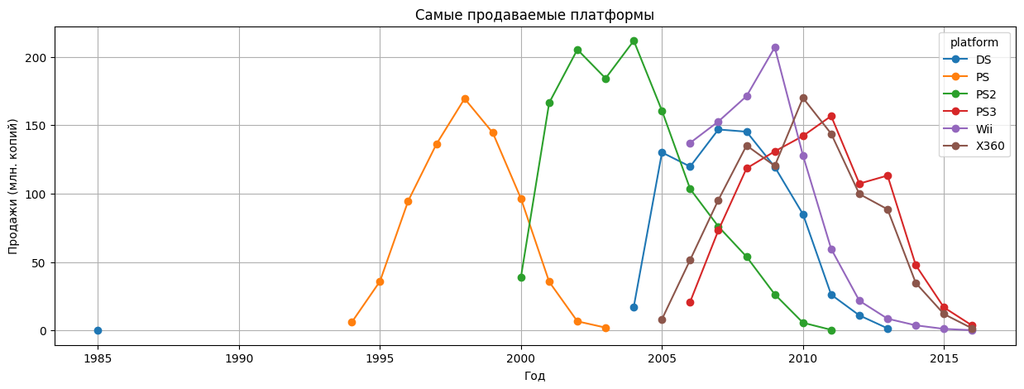

```python
(
    top_platform.pivot_table(index='year_of_release', columns='platform', values='total_sale', aggfunc='sum')
    .plot(style='o-',
          grid=True,
          figsize=(15, 5))
)

# Задание названия графика
plt.title('Самые продаваемые платформы')
plt.xlabel('Год')
plt.ylabel('Продажи (млн. копий)')

# Показать график
plt.show()
```

Необходимо удалить аномальное значение для платформы `DS`, где указан год 1985. Далее проверим уникальные значения по каждой платформе в зависимости от года, чтобы выявить возможные другие аномалии перед построением графика.

```python
top_platform = top_platform.query('year_of_release != 1985')
```

```python
def print_unique_years_by_platform(df):
    for platform in top_platform['platform'].unique():
        unique_years = top_platform[top_platform['platform'] == platform]['year_of_release'].unique()
        print(f"Платформа {platform}:")
        print(f"Уникальные year_of_release: {sorted(unique_years)}")
        print()  # Пустая строка для разделения вывода разных платформ

# Использование функции
print_unique_years_by_platform(top_platform)
```

```
Платформа Wii:
Уникальные year_of_release: [np.int64(2006), np.int64(2007), np.int64(2008), np.int64(2009), np.int64(2010), np.int64(2011), np.int64(2012), np.int64(2013), np.int64(2014), np.int64(2015), np.int64(2016)]

Платформа DS:
Уникальные year_of_release: [np.int64(2004), np.int64(2005), np.int64(2006), np.int64(2007), np.int64(2008), np.int64(2009), np.int64(2010), np.int64(2011), np.int64(2012), np.int64(2013)]

Платформа X360:
Уникальные year_of_release: [np.int64(2005), np.int64(2006), np.int64(2007), np.int64(2008), np.int64(2009), np.int64(2010), np.int64(2011), np.int64(2012), np.int64(2013), np.int64(2014), np.int64(2015), np.int64(2016)]

Платформа PS3:
Уникальные year_of_release: [np.int64(2006), np.int64(2007), np.int64(2008), np.int64(2009), np.int64(2010), np.int64(2011), np.int64(2012), np.int64(2013), np.int64(2014), np.int64(2015), np.int64(2016)]

Платформа PS2:
Уникальные year_of_release: [np.int64(2000), np.int64(2001), np.int64(2002), np.int64(2003), np.int64(2004), np.int64(2005), np.int64(2006), np.int64(2007), np.int64(2008), np.int64(2009), np.int64(2010), np.int64(2011)]

Платформа PS:
Уникальные year_of_release: [np.int64(1994), np.int64(1995), np.int64(1996), np.int64(1997), np.int64(1998), np.int64(1999), np.int64(2000), np.int64(2001), np.int64(2002), np.int64(2003)]
```

Были проверены года выпуска каждой платформы, теперь данные корректны

Построим корректный график без аномалии

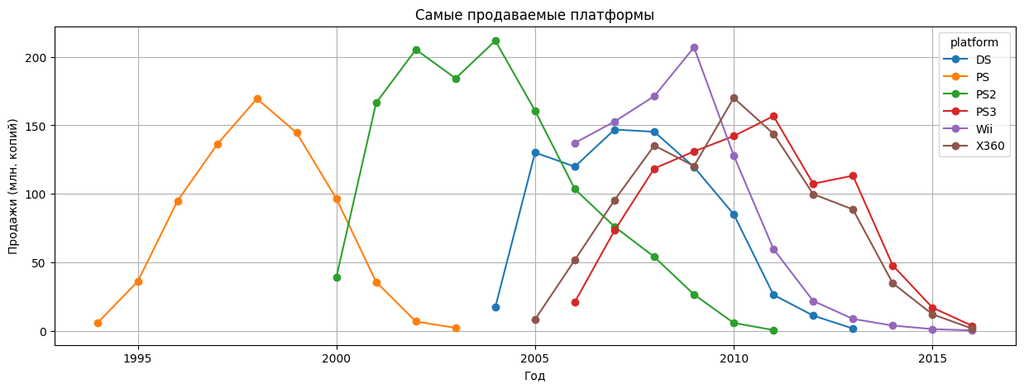

```python
(
    top_platform.pivot_table(index='year_of_release', columns='platform', values='total_sale', aggfunc='sum')
    .plot(style='o-',
          grid=True,
          figsize=(15, 5))
)

# Задание названия графика
plt.title('Самые продаваемые платформы')
plt.xlabel('Год')
plt.ylabel('Продажи (млн. копий)')

# Показать график
plt.show()
```

PS достигла пика продаж в конце 90-х годов, с резким ростом после 1995 года и максимальными продажами около 1998 года. После этого наблюдается значительное снижение, и к 2005 году продажи полностью прекращаются.

PS2 стала наиболее успешной консолью, начиная с 2000 года. Пик продаж пришелся на период с 2002 по 2004 год, после чего начался медленный спад до 2011 года.

PS3 стартовала с 2006 года, с максимальными продажами в 2011 году. После 2011 года продажи постепенно сокращаются

DS начала продажи в 2004 году, с пиком в 2007 году. После этого её продажи начали снижаться.

Wii стартовала с 2006 года и достигла пика в 2009 году. Её продажи резко упали после 2010 года.

X360 появилась в 2005 году и демонстрировала устойчивый рост до 2010 года. Пик продаж приходится на 2010 год, затем начинается спад.

**Анализ их жизненного цикла**

По графикам видно, что "жизненный цикл", составляет около 5-8 лет с момента пика продаж. Установим актуальный период с 2014 года.

Для определения актуальных платформ на 2017 год создадим таблицу `top_current_platforms` и построим графики по аналогии с таблицей `top_platform`.

```python
top_current_platforms = data.query('year_of_release >= 2014')
top_current_platforms.head(10)
```

|  | name | platform | year_of_release | genre | na_sales | eu_sales | jp_sales | other_sales | critic_score | user_score | rating | total_sale |
| --- | --- | --- | --- | --- | --- | --- | --- | --- | --- | --- | --- | --- |
| 31 | Call of Duty: Black Ops 3 | PS4 | 2015 | Shooter | 6.03 | 5.86 | 0.36 | 2.38 | -1.0 | -2.0 | unknown | 14.63 |
| 42 | Grand Theft Auto V | PS4 | 2014 | Action | 3.96 | 6.31 | 0.38 | 1.97 | 97.0 | 8.3 | M | 12.62 |
| 47 | Pokemon Omega Ruby/Pokemon Alpha Sapphire | 3DS | 2014 | Role-Playing | 4.35 | 3.49 | 3.10 | 0.74 | -1.0 | -2.0 | unknown | 11.68 |
| 77 | FIFA 16 | PS4 | 2015 | Sports | 1.12 | 6.12 | 0.06 | 1.28 | 82.0 | 4.3 | E | 8.58 |
| 87 | Star Wars Battlefront (2015) | PS4 | 2015 | Shooter | 2.99 | 3.49 | 0.22 | 1.28 | -1.0 | -2.0 | unknown | 7.98 |
| 92 | Call of Duty: Advanced Warfare | PS4 | 2014 | Shooter | 2.81 | 3.48 | 0.14 | 1.23 | 83.0 | 5.7 | M | 7.66 |
| 94 | FIFA 17 | PS4 | 2016 | Sports | 0.66 | 5.75 | 0.08 | 1.11 | 85.0 | 5.0 | E | 7.60 |
| 96 | Super Smash Bros. for Wii U and 3DS | 3DS | 2014 | Fighting | 3.27 | 1.37 | 2.43 | 0.48 | -1.0 | -2.0 | unknown | 7.55 |
| 99 | Call of Duty: Black Ops 3 | XOne | 2015 | Shooter | 4.59 | 2.11 | 0.01 | 0.68 | -1.0 | -2.0 | unknown | 7.39 |
| 105 | Fallout 4 | PS4 | 2015 | Role-Playing | 2.53 | 3.27 | 0.24 | 1.13 | 87.0 | 6.5 | M | 7.17 |

```python
top_current_platforms['platform'].unique().tolist()
```

```
['PS4', '3DS', 'XOne', 'WiiU', 'PS3', 'X360', 'PC', 'Wii', 'PSV', 'PSP']
```

Определены актуальные платформы, начиная с 2014 года

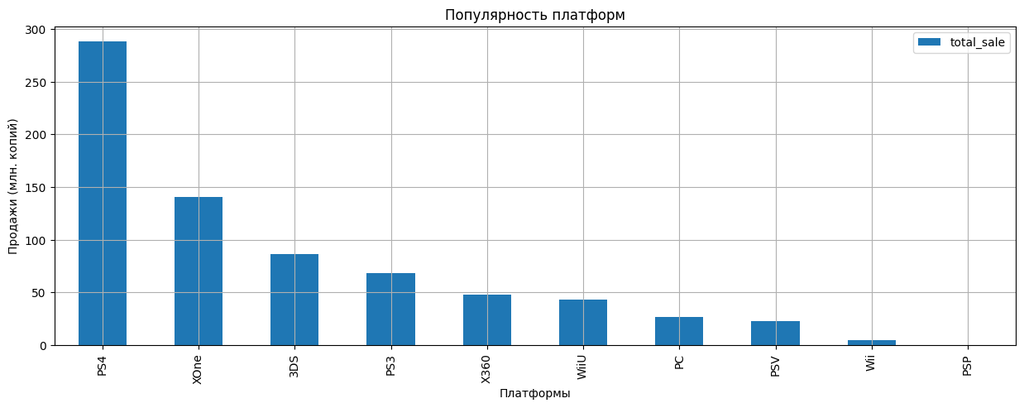

```python
# Построим график
(
    top_current_platforms.pivot_table(index='platform', values='total_sale', aggfunc='sum')
    .sort_values('total_sale', ascending=False)
    .plot(kind='bar',
          grid=True,
          figsize=(15, 5))
)

# Задание названия графика
plt.title('Популярность платформ')
plt.xlabel('Платформы')
plt.ylabel('Продажи (млн. копий)')

# Показать график
plt.show()
```

Платформа PS4 лидирует по объему продаж начиная с 2014 года. В то же время PSP является самой непопулярной платформой

Построим график 'жизненного цикла' для всех полученных платформ начиная, с 2009 года

```python
platforms_list = top_current_platforms['platform'].unique().tolist()

top_current_platforms_temp = data.query('platform in @platforms_list and year_of_release >= 2009')
top_current_platforms_temp.head(10)
```

|  | name | platform | year_of_release | genre | na_sales | eu_sales | jp_sales | other_sales | critic_score | user_score | rating | total_sale |
| --- | --- | --- | --- | --- | --- | --- | --- | --- | --- | --- | --- | --- |
| 3 | Wii Sports Resort | Wii | 2009 | Sports | 15.61 | 10.93 | 3.28 | 2.95 | 80.0 | 8.0 | E | 32.77 |
| 8 | New Super Mario Bros. Wii | Wii | 2009 | Platform | 14.44 | 6.94 | 4.70 | 2.24 | 87.0 | 8.4 | E | 28.32 |
| 14 | Kinect Adventures! | X360 | 2010 | Misc | 15.00 | 4.89 | 0.24 | 1.69 | 61.0 | 6.3 | E | 21.82 |
| 15 | Wii Fit Plus | Wii | 2009 | Sports | 9.01 | 8.49 | 2.53 | 1.77 | 80.0 | 7.4 | E | 21.80 |
| 16 | Grand Theft Auto V | PS3 | 2013 | Action | 7.02 | 9.09 | 0.98 | 3.96 | 97.0 | 8.2 | M | 21.05 |
| 23 | Grand Theft Auto V | X360 | 2013 | Action | 9.66 | 5.14 | 0.06 | 1.41 | 97.0 | 8.1 | M | 16.27 |
| 29 | Call of Duty: Modern Warfare 3 | X360 | 2011 | Shooter | 9.04 | 4.24 | 0.13 | 1.32 | 88.0 | 3.4 | M | 14.73 |
| 31 | Call of Duty: Black Ops 3 | PS4 | 2015 | Shooter | 6.03 | 5.86 | 0.36 | 2.38 | -1.0 | -2.0 | unknown | 14.63 |
| 32 | Call of Duty: Black Ops | X360 | 2010 | Shooter | 9.70 | 3.68 | 0.11 | 1.13 | 87.0 | 6.3 | M | 14.62 |
| 33 | Pokemon X/Pokemon Y | 3DS | 2013 | Role-Playing | 5.28 | 4.19 | 4.35 | 0.78 | -1.0 | -2.0 | unknown | 14.60 |

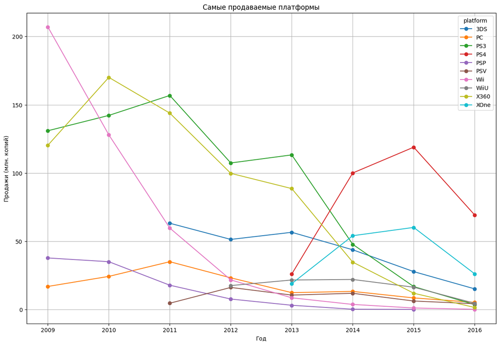

```python
(
    top_current_platforms_temp.pivot_table(index='year_of_release', columns='platform', values='total_sale', aggfunc='sum')
    .plot(style='o-',
          grid=True,
          figsize=(15, 10))
)

# Задание названия графика
plt.title('Самые продаваемые платформы')
plt.xlabel('Год')
plt.ylabel('Продажи (млн. копий)')

# Показать график
plt.show()
```

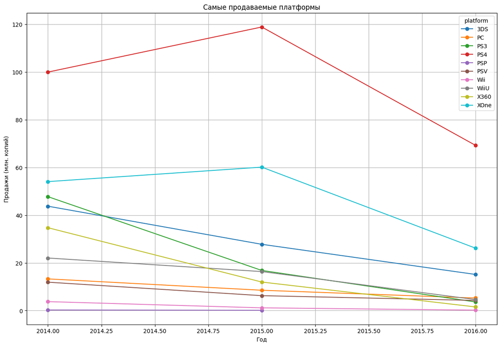

```python
(
    top_current_platforms.pivot_table(index='year_of_release', columns='platform', values='total_sale', aggfunc='sum')
    .plot(style='o-',
          grid=True,
          figsize=(15, 10))
)

# Задание названия графика
plt.title('Самые продаваемые платформы')
plt.xlabel('Год')
plt.ylabel('Продажи (млн. копий)')

# Показать график
plt.show()
```

**Построим график «ящик с усами» по глобальным продажам игр в разбивке по платформам.**

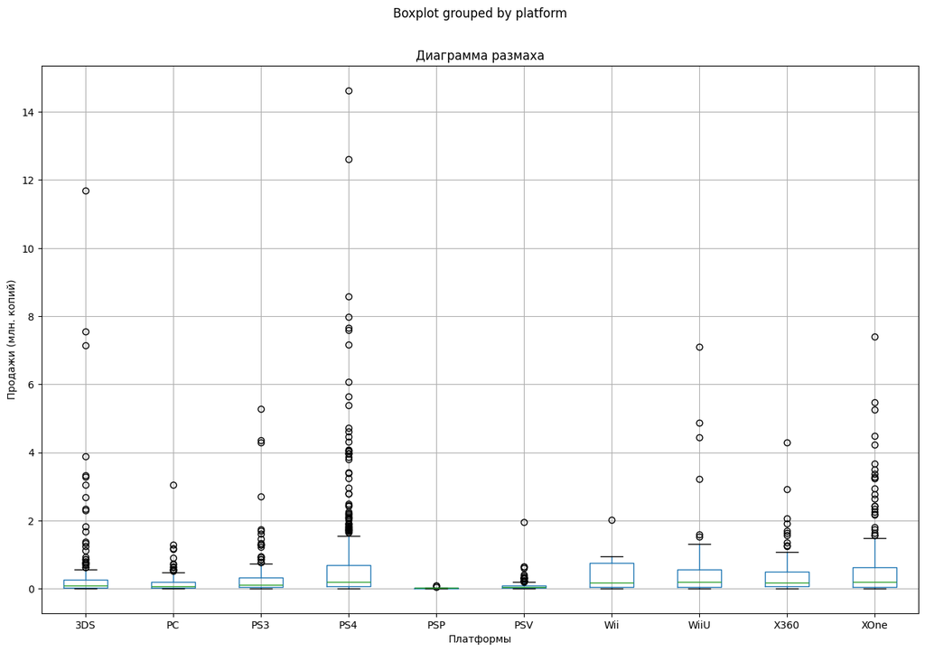

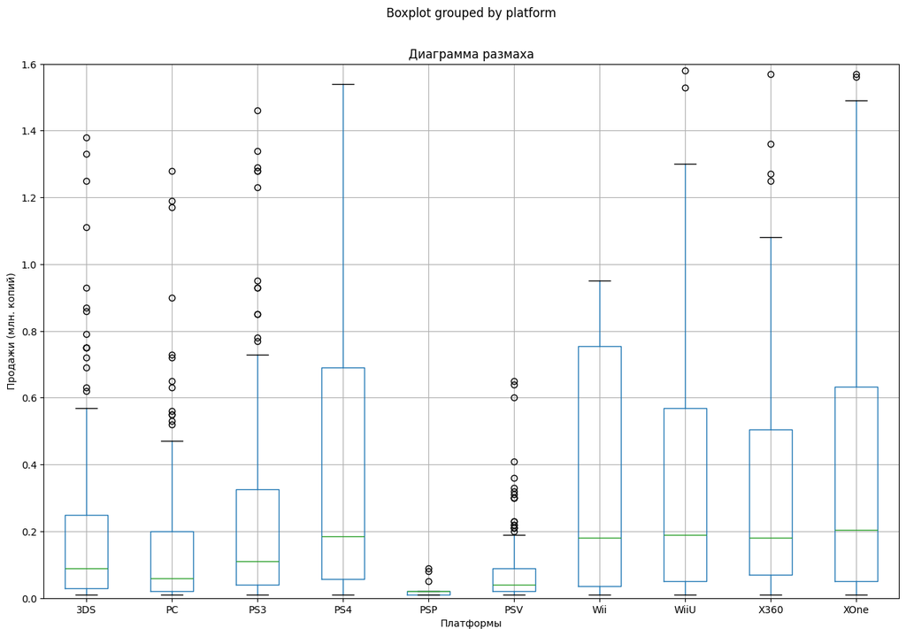

```python
top_current_platforms.boxplot(
    by='platform',
    column='total_sale',
    figsize=(15, 10),
    vert=True)

# Задание названия графика
plt.title('Диаграмма размаха')
plt.xlabel('Платформы')
plt.ylabel('Продажи (млн. копий)')

# Показать график
plt.show()

top_current_platforms.boxplot(
    by='platform',
    column='total_sale',
    figsize=(15, 10),
    vert=True)

plt.ylim(0, 1.6)
# Задание названия графика
plt.title('Диаграмма размаха')
plt.xlabel('Платформы')
plt.ylabel('Продажи (млн. копий)')

# Показать график
plt.show()
```